# Sesion 23 - Laboratorio

Juan Carlos Martinez-Ovando

Departamento Academico de Actuaria

Primavera 2019

# 1 Modelo de severidades individuales

Consideremos, como en ocasiones previas, los datos de `AllState`:

```r
data <- read.csv("./Datos/d4a_allstateclaim_data.csv")
head(data)
```

```
##   Household_ID Vehicle Calendar_Year Model_Year Blind_Make Claim_Amount
## 1            1       3          2005       2005          K            0
## 2            2       2          2005       2003          Q            0
## 3            3       1          2005       1998         AR            0
## 4            3       1          2006       1998         AR            0
## 5            3       2          2005       2001          D            0
## 6            3       2          2006       2001          D            0
```

```r
colnames(data)
```

```
## [1] "Household_ID"  "Vehicle"       "Calendar_Year" "Model_Year"
## [5] "Blind_Make"    "Claim_Amount"
```

Recordemos, los datos corresponden a reclamos por polizas de un seguro de autos de la empresa *AllState*. Se supone que cada poliza es contratada por un hogar. Los montos de reclamos para las diferentes polizas pueden diferenciarse por anio de suscripcion, modelo del vehiculo y fabricante.

## 1.1 Diccionario

- `Household_ID` INT - Identificador numerico de la poliza (una por hogar).
- `Vehicle` INT - Identificador del vehiculo asegurado por poliza (dentro de cada hogar).
- `Calendar_Year` INT - Anio calendario en el que el vehiculo fue asegurado.
- `Model_Year` INT - Anio calendario de fabricacion/venta del vehiculo.
- `Blind_Make` INT - Fabricante del vehiculo (discresional).
- `Claim_Amount` INT - Monto de reclamo asociado con el vehiculo (montos en USD).

**Nota:-** Las polizas con reclamos nulos (`Claim_Amount`==0) corresponden a casos no siniestrados.

## 1.2 Datos de severidades individuales

Los datos que son de interes para nosotros, en este laboratorio, son los de `severidades individuales` condicionales en la `ocurrencia de siniestros`.

Estos datos corresponden a los casos donde `Claim_Amount`>0). Para esto, filtramos los datos para recuperar las severidades individuales.

```r
indices <- which(data$Claim_Amount > 0)
severidades <- data[indices,]
dim(severidades)
```

```
## [1] 8430    6
```

```r
table(severidades$Calendar_Year)
```

```
##
## 2005 2006 2007
## 3001 2749 2680
```

Conservamos todas las variables, porque realizaremos un ejercicio de diversificacion mas adelante. En particular, referente a el *anio calendario* (`Calendar_Year`) y al fabricante del vehiculo (`Blind_Make`).

```r
table(severidades[,c("Calendar_Year","Blind_Make")])
```

```
##              Blind_Make
## Calendar_Year   ?  AC  AD  AE  AF  AG  AH  AI  AJ  AK  AL  AM  AN  AO  AP
##          2005   1   4   0   0   6   0  79  20 453   0  27   0  24  69   0
##          2006   0  10   0   0   2   0  66   9 356   0  23   0  23  86   0
##          2007   2   2   0   0   5   0  37  15 282   0  12   0  19  80   0
##              Blind_Make
## Calendar_Year  AQ  AR  AT  AU  AV  AW  AX  AY  AZ   B  BA  BB  BC  BD  BF
##          2005  38  40   0 233  21   2  16   7   6   0   0   1   0   2  55
##          2006  50  35   0 200  16   1   9   6   3   0   0   4   0   5  47
##          2007  56  31   0 173  15   2  10   7   2   0   0   3   0   4  62
##              Blind_Make
## Calendar_Year  BG  BH  BK  BL  BM  BN  BO  BP  BQ  BR  BS  BT  BU  BV  BW
##          2005   0  40   0   0   0   2 152  33   0   0   0  19  38  63 294
##          2006   1  36   0   0   0   2 145  22   0   1   0  19  50  66 284
##          2007   1  33   0   0   2   2 126  47   0   0   0  17  34  58 238
##              Blind_Make
## Calendar_Year  BY  BZ  CB   D   E   F   G   I   J   K   L   M   N   O   P
##          2005   3  10   0  29   0   0   6  13   2 337  98  39  12  20  47
##          2006   1   9   0  27   0   0   3   9  10 282  96  55  10  20  25
##          2007   2  14   0  27   0   0   6  11  13 271 140  68   4  20  28
##              Blind_Make
## Calendar_Year   Q   R   S   U   V   W   X   Y   Z
##          2005  45  28   0   0   1  97 246 213  10
##          2006  49  32   0   0   1  80 216 237  10
##          2007  58  38   0   0   0  97 241 263   2
```

De momento, en este laboratorio, solo consideraremos los datos `Claim_Amount`.

**Nota:-** Recordemos que los datos de `montos/severidades individuales` son reportados en la misma base monetaria, por lo que estos son comparables entre los casos `2005`, `2006` y `2007`.

Observemos la comparacion de los datos entre anios:

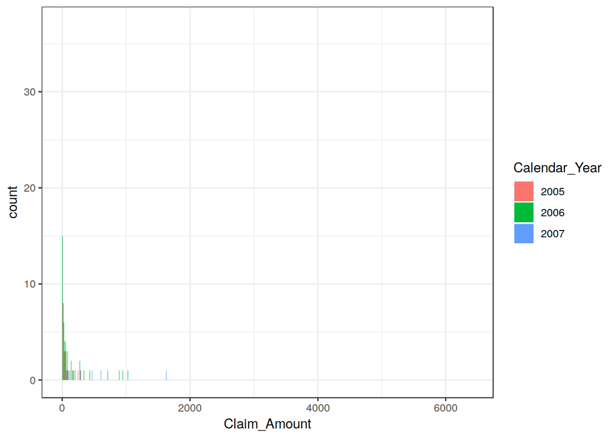

```r
if(!require("ggplot2")){install.packages("ggplot2")}
library("ggplot2")

severidades$Calendar_Year <- as.factor(severidades$Calendar_Year)

ggplot(severidades[,c("Calendar_Year","Claim_Amount")], aes(x=Claim_Amount,group=Calendar_Year,fill=Calendar_Year))+
  geom_histogram(position="dodge",binwidth=0.25)+theme_bw()
```

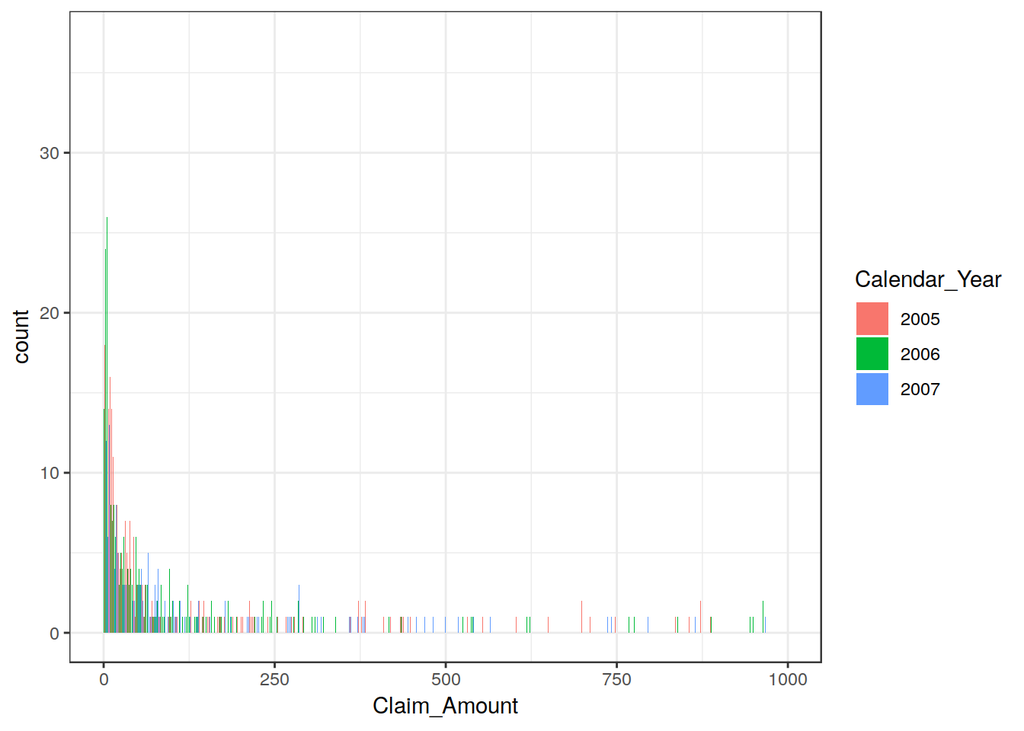

```r
ggplot(severidades[which(severidades$Claim_Amount<1000),c("Calendar_Year","Claim_Amount")], aes(x=Claim_Amount,group=Calendar_Year,fill=Calendar_Year))+
  geom_histogram(position="dodge",binwidth=0.25)+theme_bw()
```

*Grosso modo*, los datos comparten el mismo comportamiento:

**2005**

```r
summary(severidades[which(severidades$Calendar_Year=="2005"),"Claim_Amount"])
```

```
##     Min.  1st Qu.   Median     Mean  3rd Qu.     Max.
##    0.049   10.139   35.947  173.669  132.776 6422.466
```

**2006**

```r
summary(severidades[which(severidades$Calendar_Year=="2006"),"Claim_Amount"])
```

```
##     Min.  1st Qu.   Median     Mean  3rd Qu.     Max.
##    0.003    9.876   35.895  181.778  141.500 4902.777
```

**2007**

```r
summary(severidades[which(severidades$Calendar_Year=="2007"),"Claim_Amount"])
```

```
##     Min.  1st Qu.   Median     Mean  3rd Qu.     Max.
##    0.023   10.484   39.552  157.904  145.546 3679.300
```

Observamos un patron marginalmente diferenciado de los datos de `2005` y `2006` respecto a `2007` en terminos de los siguientes aspectos de su distribucion asociada:

- **Sesgo**
- **Peso de la cola derecha**

Examinaremos estos aspectos con detalle mas adelante. Por lo pronto, consideremos los siguientes escenarios de `entrenamiento` y `prueba`.

## 1.3 Escenarios de aprendizaje

Consideraremos los siguientes dos escenarios de aprendizaje:

> **Aprendizaje I:-** Datos de `entrenamiento` para `2005` y de `prueba` para `2006`.

> **Aprendizaje II:-** Datos de `entrenamiento` para `2005,2006` y de `prueba` para `2007`.

# 2 Modelos

Recordemos, en este laboratorio solo estamos prestando atencion al estudio de la `distribucion de severidades individuales`. De esta forma, y de manera consistente con las distribuciones de la `session 22` de nuestro curso, porponemos los siguientes modelos:

1. Funcion de distribucion empirica (EDF, por sus siglas en ingles)

Obtendremos la estimacion de la EDF empleando la libreria `EnvStats`. Recuerden, que el calculo es relativamente sencillo de obtener sin emplear esta libreria.

2. Distribucion Pareto

La estimacion por `maxima verosimilitud` y `minimos cuadrados` de la distribucion Pareto se obtiene en `R` empleando la libreria `EnvStats`.

3. Distribucion Lognormal

La estimacion de parametros via `maxima verosimilitud` de la distribucion lognormal la obtendremos empleando la libreria `MASS`. Recuerden que la estimacion directa es relativamente sencilla, tambien.

4. Distribucion gamma generalizada

La estimacion por `maxima verosimilitud` de los tres parametros de la distribucion gamma generalizada puede obtnerse empleando la libreria `VGAM`.

5. Distribucion beta generalizada del segundo tipo

La estimacion de los parametros de la distribucion beta generalizada del segundo tipo la obtendremos via `maxima varosimilitud` empleando la libreria `GB2`.

6. Distribucion Pareto generalizada

La estimacion de los parametros de la distribucion Pareto generalizada empleando `maxima verosimilitud` puede obtenerse empleando la libreria `evir`. Esta libreria incluye otros metodos de estimacion, de manera alternativa, pero no los consideraremos en este laboratorio.

```
if(!require("EnvStats")){install.packages("EnvStats")}
if(!require("VGAM")){install.packages("VGAM")}
if(!require("MASS")){install.packages("MASS")}
if(!require("GB2")){install.packages("GB2")}
if(!require("evir")){install.packages("evir")}
```

# 3 Aprendizaje I

En el `Aprendizaje I` consideramos los datos de `2005` como `datos de entrenamiento` y los de `2006` como `datos de prueba`.

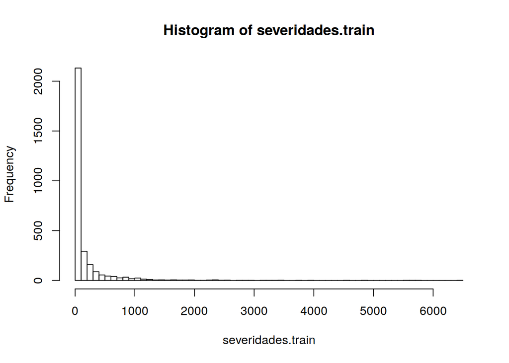

```r
severidades.train <- severidades[which(severidades$Calendar_Year=="2005"),"Claim_Amount"]
severidades.test <- severidades[which(severidades$Calendar_Year=="2006"),"Claim_Amount"]
hist(severidades.train,50)
```

## 3.1 Funcion de distribucion empirica

La estimacion de la $edf$ se obtiene con la siguiente instruccion:

```r
library("EnvStats")
p <- qemp(p = seq(0, 1, len = 100), severidades.train)
f.edf <- demp(p, severidades.train)
```

La visualizacion de la $edf$ en los datos se obtiene como:

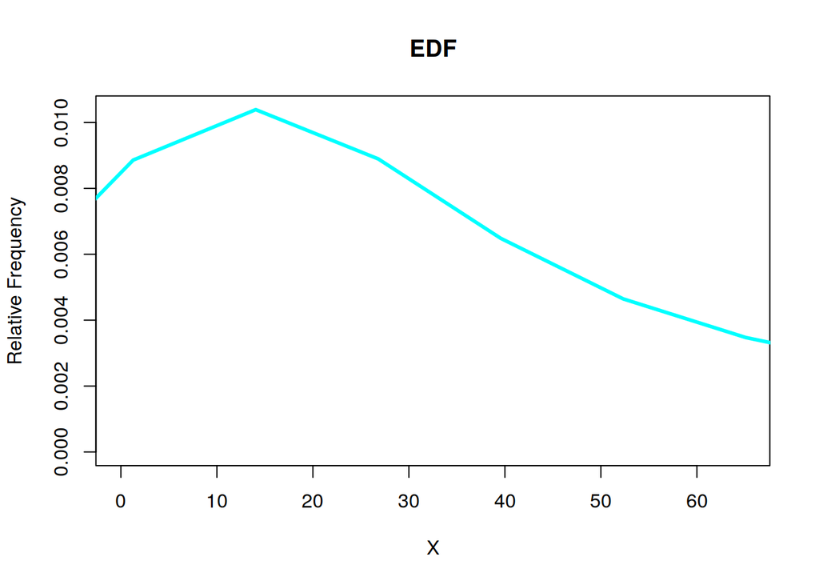

```r
epdfPlot(severidades.train,
         xlim = c(0, 65),
         epdf.col = "cyan",
         xlab = "X",
         main = "EDF")
```

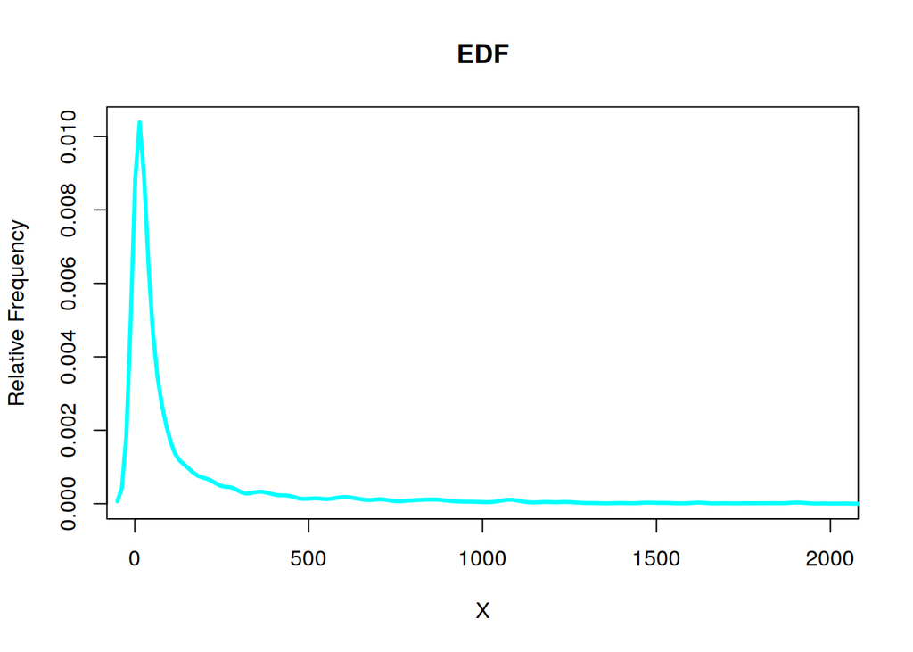

```r
epdfPlot(severidades.train,
         xlim = c(0, 2000),
         epdf.col = "cyan",
         xlab = "X",
         main = "EDF")
```

## 3.3 Distribucion Lognormal

La estimacion de la distirbucion log-normal se obtiene de la siguiente forma:

```r
library("MASS")
par.lognorm <- fitdistr(severidades.train,"lognormal")
par.lognorm
```

```
##     meanlog       sdlog
##   3.60458741   1.83813098
##  (0.03355393) (0.02372621)
```

La densidad de la distribucion estimada es:

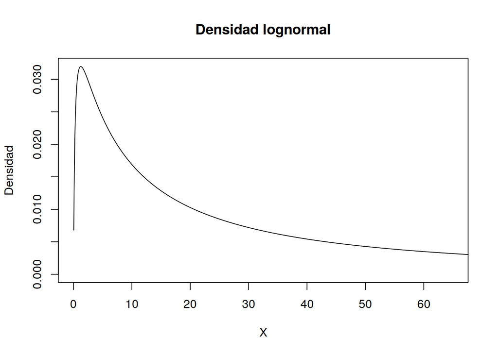

```r
severidades.train.unique <- sort(unique(severidades.train))
d.lognorm <- dlnorm(severidades.train.unique,
                    par.lognorm$estimate['meanlog'],
                    par.lognorm$estimate['sdlog'])

plot(severidades.train.unique, d.lognorm, type="l",
     ylab="Densidad",
     xlab="X",
     xlim=c(0,65))
title(main = "Densidad lognormal")
```

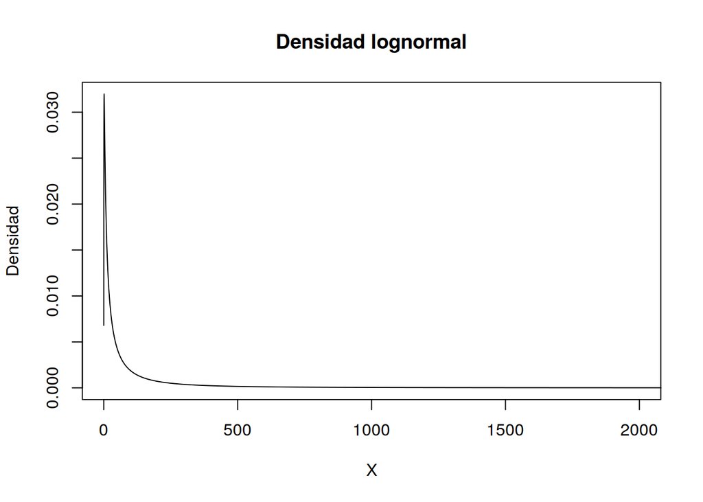

```r
plot(severidades.train.unique, d.lognorm, type="l",
     ylab="Densidad",
     xlab="X",
     xlim=c(0,2000))
title(main = "Densidad lognormal")
```

## 3.5 Distribucion beta generalizada del segundo tipo

La estimacion de los parametros de la distribucion beta generalizada del segundo tipo se obtene de la siguiente forma:

```r
library("GB2")
par.gb2 <- mlfit.gb2(severidades.train)
```

```
## [1] Warning: negative parameter
```

```r
par.gb2
```

```
## [[1]]
##       type median mean  ARPR    RMPG    QSR GINI likelihood    a     b
## 1 Emp. est     36  174 39.95   65.57 197.95 0.77         NA   NA    NA
## 2  ML full     36  238 38.88   63.34 278.35 0.84      5.634 0.31 18.90
## 3  ML prof     37  199 60.95 -326.24   0.00   NA      5.632 0.00 31.82
##              p            q
## 1           NA           NA
## 2 7.440000e+00 6.160000e+00
## 3 1.966235e+10 1.966237e+10
##
## [[2]]
## [[2]]$par
## [1]  0.3061713 18.9009652  7.4430120  6.1609407
##
## [[2]]$value
## [1] 5.634306
##
## [[2]]$counts
## function gradient
##      105       85
##
## [[2]]$convergence
## [1] 0
##
## [[2]]$message
## NULL
##
##
## [[3]]
## [[3]]$par
## [1] -5.486820e-06  3.182346e+01
##
## [[3]]$value
## [1] 5.632275
##
## [[3]]$counts
## function gradient
##       33       11
##
## [[3]]$convergence
## [1] 0
##
## [[3]]$message
## NULL
```

# 4 Comparacion de modelos

1. Bondad de ajuste
2. Cociente de verosimilitud
3. Cociente de veroimilitud extendida

## 4.1 Bondad de ajuste

Este enfoque basicamente consiste en contrastar los **cinco modelos parametricos** en terminos de sus `cercania/semejanza` con la **EDF**.

Los criterios difieren, escencialmente, en la `metrica` empleada para calcular la `cercania/semejanza` entre distribuciones.

Definimos, de manera general, a $F_{edf}(X)$ como la funcion de distirbucion empirica y $F_j(x|\hat{\theta}_j)$ como la distirbucion parametrica estimada (puntualmente) del tipo de modelo $j$.

### 4.1.1 Kolmogorov-Smirnov

El estadistico para medir la `cercania/semejanza` entre distribuciones $edf$ y $j$ bajo Kolmogorov-Smirnov (KS) es
$$T_{KS}(j)=\max_{x}|F_{edf}(x)-F_j(x|\hat{\theta}_j)|,$$
para $j=1,\ldots,J$.

**Nota.** La $edf$ es discreta, por lo que el calculo de $T_{KS}(j)$ debe realizarse en dos puntos para cada valor de $x$:

- $F_{edf}(x-)$ que es el limite por la izquierda antes de $x$
- $F_{edf}(x)$ que es el limite por la derecha antes de $x$.

Los valores criticos tradicionalmente empleados para esta estadistica son:

1. $T_\alpha=\frac{1.22}{\sqrt{n}}$ para $\alpha=0.10$ nivel de significacia,
2. $T_\alpha=\frac{1.36}{\sqrt{n}}$ para $\alpha=0.05$ nivel de significacia,
3. $T_\alpha=\frac{1.63}{\sqrt{n}}$ para $\alpha=0.01$ nivel de significacia,

donde $n$ es el tamnio de la muestra.

### 4.1.2 Anderson-Darling

En la opcion anderson-Darling (AD), la metrica para medir la `cercania/semejanza` entre distribuciones $edf$ y $j$ es definida como
$$T_{AD}(j)=-nF_j(x^*_U|\hat{\theta}_j)
+n\sum_{u=1}^{U-1} [1-F_{edf}(x^*_u)]^2 \left\{\text{log}[1-F_j(x^*_u|\hat{\theta}_j)]-\text{log}[1-F_j(x^*_{u+1}|\hat{\theta}_j)]\right\}
+ n \sum_{u=2}^{U} F_{edf}(x_u^*)^2 \left[\text{log}F_j(x^*_{u+1}|\hat{\theta}_j)-\text{log}F_j(x^*_u|\hat{\theta}_j)\right],$$
donde $\{x_u^*\}_{u=1}^{U}$ corresponden a los $U$ datos unicos disponibles.

**Nota:** En este calculo, se hace explicito la consideracion de comparacion entre `limites por la derecha` y `limites por la izquierda` relacionados con $F_{edf}(\cdot)$.

Los valores critios, para esta prueba, son tipicamente:

1. $T_a=1.933$ para $a=0.10$,
2. $T_a=2.492$ para $a=0.05$,
3. $T_a=3.857$ para $a=0.01$.

## 4.2 Verosimilitud

El cociente de verosimilitudes, consiste basicamente en calcular la `verosimilitud del modelo especifico` para los datos. Esta verosimilitud se calcula en dos pasos.

1. Calcula el `estimador puntual` (via `maxima verosimilitud`) de `\theta_j`, para `j=1,\ldots,J`, con base en los datos $\{x_1,\ldots,x_n\}$.

Recuerden, de los datos extraemos los datos unicos $\{x_1^*,\ldots,x_U^*\}$ (las frecuencias de los datos unicos no son requeridas en este contexto).

2. Con el `estimador puntual del modelo especifico`, $F_{j}(x|\hat{\theta}_j)$, recuperamos su correspondiente densidad y calculamos la `verosimilitud del modelo` $j$ de la siguiente forma:
   $$lik(j)=\prod_{u=1}^{U}f_j(x_u^*|\hat{\theta}_{j}),$$
   para $j=1,\ldots,J$.

Por cuestiones numericas, es conveniente trabajar con la `log-verosimilitud`,
$$loglik(j)=\sum_{u=1}^{U} \text{log}f_j(x_u^*|\hat{\theta}_{j}).$$

**Noten** que la verosimilitud del modelo se calcula sobre un segmento de los mismos datos con los que se estimo el modelo, `datos de entrenamiento`.

## 4.3 Verosimilitud predictiva

Una variante del `procedimiento basado en verosimilitud` para evaluar la capacidad predictiva del modelo consiste en realizar la siguiente modificacion:
$$ploglik(j)=\sum_{u=1}^{U} \text{log}f_j(x_u^t|\hat{\theta}_{j}),$$
donde $\{x_u^t\}_{u=1}^{U}$ corresponden a los $U$ valores unicos de los `datos de prueba/test`.

**Noten** que la evaluacion de las densidades en los datos de prueba brinda una cuantificacion de que tanta masa de probabilidad el modelo predictivo asigna a los valores que realmente ocurrieron (pero que no fueron empleados en el proceso de estimacion).

# 5 Ejercicios

- Realizar el procedimiento de `Aprendizaje II`